# BusinessMetrics

### Zone-Based Model Accuracy

Model performance is evaluated per zone using:

- MAE
- Relative error

This allows us to see how prediction accuracy changes across different demand levels.

The focus is on High-demand zones, where most rides and revenue are generated.  
Errors in these areas have the greatest impact on driver allocation and service performance.

The results below show:

- which zones are predicted most accurately
- how error behaves across busy vs low-demand areas
- whether the model is reliable in the parts of the city that matter most

```
Top 10 best zones by relative demand error (%):
```

|  | PULocationID | Zone | mean_actual_demand | mean_pred_demand | mae | rmse | mape_pct | n_obs | relative_mae_pct |
| --- | --- | --- | --- | --- | --- | --- | --- | --- | --- |
| 53 | 237 | Upper East Side South | 195.04 | 198.00 | 23.07 | 36.57 | 19.98 | 396 | 11.83 |
| 51 | 234 | Union Sq | 109.63 | 111.13 | 14.02 | 20.84 | 23.71 | 396 | 12.79 |
| 52 | 236 | Upper East Side North | 179.75 | 182.93 | 24.02 | 37.81 | 24.49 | 380 | 13.36 |
| 36 | 163 | Midtown North | 114.22 | 113.93 | 15.67 | 23.30 | 26.00 | 406 | 13.72 |
| 25 | 140 | Lenox Hill East | 76.66 | 79.85 | 10.61 | 16.33 | 22.86 | 402 | 13.83 |
| 10 | 68 | East Chelsea | 109.44 | 111.82 | 15.19 | 21.52 | 22.93 | 407 | 13.88 |
| 39 | 170 | Murray Hill | 109.57 | 109.87 | 15.51 | 22.08 | 20.89 | 407 | 14.15 |
| 26 | 141 | Lenox Hill West | 91.28 | 92.51 | 12.95 | 19.31 | 21.40 | 408 | 14.19 |
| 37 | 164 | Midtown South | 92.34 | 92.19 | 13.34 | 18.88 | 21.34 | 407 | 14.45 |
| 34 | 161 | Midtown Center | 183.56 | 182.20 | 27.46 | 41.65 | 24.61 | 405 | 14.96 |

```
Top 10 worst zones by relative demand error (%):
```

|  | PULocationID | Zone | mean_actual_demand | mean_pred_demand | mae | rmse | mape_pct | n_obs | relative_mae_pct |
| --- | --- | --- | --- | --- | --- | --- | --- | --- | --- |
| 1 | 12 | Battery Park | 4.48 | 4.47 | 2.20 | 2.84 | 76.97 | 114 | 48.97 |
| 57 | 244 | Washington Heights South | 3.70 | 3.25 | 1.65 | 2.29 | 61.32 | 156 | 44.66 |
| 32 | 152 | Manhattanville | 3.29 | 2.92 | 1.47 | 1.91 | 60.24 | 161 | 44.66 |
| 21 | 116 | Hamilton Heights | 3.15 | 3.02 | 1.38 | 1.86 | 58.95 | 161 | 43.93 |
| 5 | 42 | Central Harlem North | 4.57 | 4.40 | 1.87 | 2.46 | 57.90 | 263 | 40.95 |
| 49 | 232 | Two Bridges/Seward Park | 5.14 | 5.08 | 2.06 | 2.99 | 66.60 | 261 | 40.18 |
| 45 | 224 | Stuy Town/Peter Cooper Village | 5.24 | 4.85 | 2.09 | 2.82 | 59.51 | 282 | 39.93 |
| 56 | 243 | Washington Heights North | 1.79 | 1.40 | 0.70 | 0.83 | 37.48 | 14 | 39.20 |
| 0 | 4 | Alphabet City | 7.90 | 7.89 | 3.02 | 5.36 | 74.30 | 185 | 38.20 |
| 7 | 45 | Chinatown | 7.94 | 8.21 | 2.65 | 3.46 | 54.53 | 268 | 33.44 |

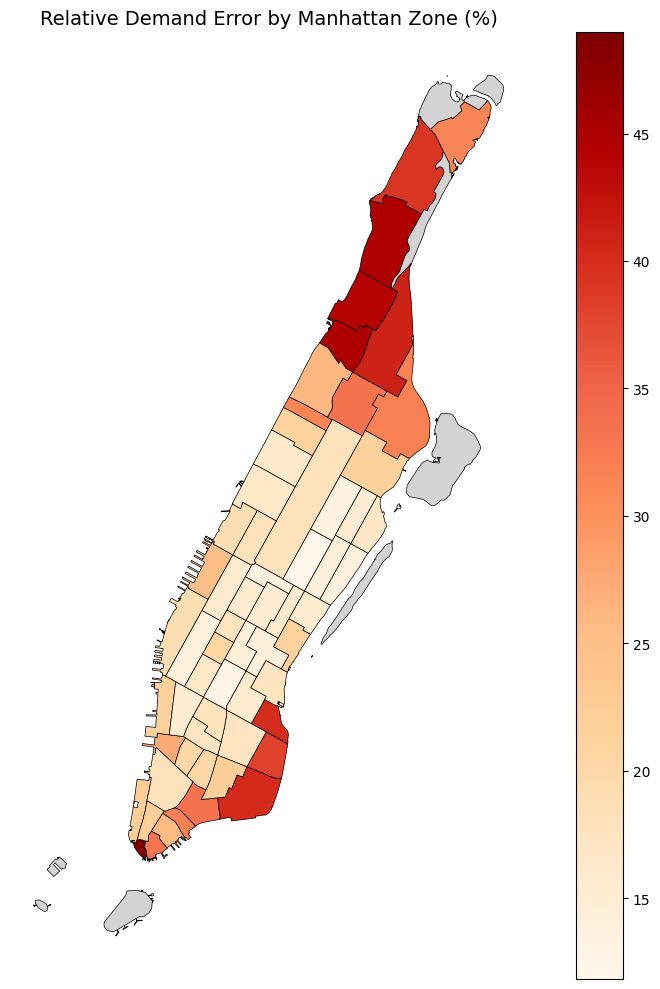

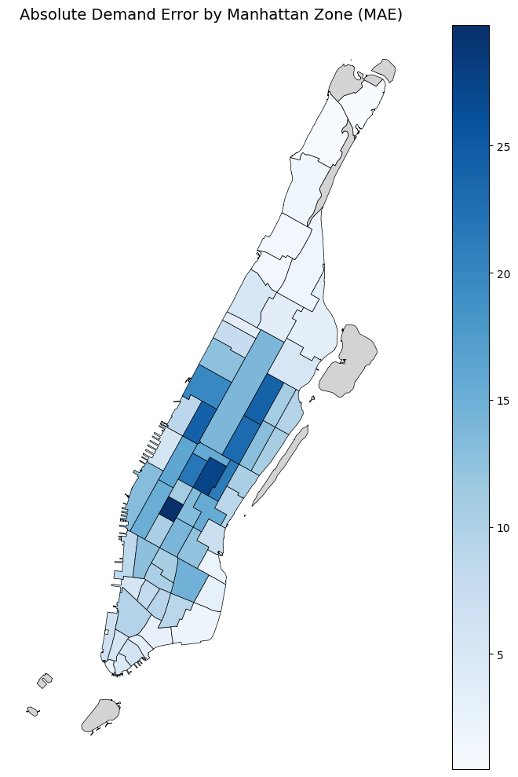

```
Saved:
 - zone_error_map.png
 - zone_abs_error_map.png
```

```python
import pandas as pd
import numpy as np
import geopandas as gpd
import matplotlib.pyplot as plt
from pathlib import Path
import matplotlib as mpl

PRED_PATH = Path("predictions.csv")
SHAPEFILE_PATH = Path("data") / "taxi_zones" / "taxi_zones.shp"

pred_df = pd.read_csv(PRED_PATH)
zones_geo = gpd.read_file(SHAPEFILE_PATH)

required_pred_cols = {
    "PULocationID", "Zone", "Predicted_Demand", "Actual_Demand"
}
missing_pred = required_pred_cols - set(pred_df.columns)
if missing_pred:
    raise ValueError(f"predictions.csv is missing required columns: {missing_pred}")

zones_geo.columns = [c.strip() for c in zones_geo.columns]

possible_location_cols = ["LocationID", "locationid", "OBJECTID"]
loc_col = next((c for c in possible_location_cols if c in zones_geo.columns), None)
if loc_col is None:
    raise ValueError(
        f"Could not find a location ID column in shapefile. Found columns: {list(zones_geo.columns)}"
    )

possible_borough_cols = ["borough", "Borough"]
borough_col = next((c for c in possible_borough_cols if c in zones_geo.columns), None)
if borough_col is None:
    raise ValueError(
        f"Could not find a borough column in shapefile. Found columns: {list(zones_geo.columns)}"
    )

possible_zone_cols = ["zone", "Zone"]
zone_col = next((c for c in possible_zone_cols if c in zones_geo.columns), None)
if zone_col is None:
    raise ValueError(
        f"Could not find a zone name column in shapefile. Found columns: {list(zones_geo.columns)}"
    )

pred_df = pred_df.copy()
pred_df["abs_error"] = (pred_df["Predicted_Demand"] - pred_df["Actual_Demand"]).abs()
pred_df["sq_error"] = (pred_df["Predicted_Demand"] - pred_df["Actual_Demand"]) ** 2

# Relative error
pred_df["ape_pct"] = np.where(
    pred_df["Actual_Demand"] > 0,
    pred_df["abs_error"] / pred_df["Actual_Demand"] * 100,
    np.nan
)

zone_eval = (
    pred_df.groupby(["PULocationID", "Zone"], as_index=False)
    .agg(
        mean_actual_demand=("Actual_Demand", "mean"),
        mean_pred_demand=("Predicted_Demand", "mean"),
        mae=("abs_error", "mean"),
        rmse=("sq_error", lambda x: np.sqrt(np.mean(x))),
        mape_pct=("ape_pct", "mean"),
        n_obs=("Actual_Demand", "size"),
    )
)

zone_eval["relative_mae_pct"] = np.where(
    zone_eval["mean_actual_demand"] > 0,
    zone_eval["mae"] / zone_eval["mean_actual_demand"] * 100,
    np.nan
)
zone_eval = zone_eval[~zone_eval["PULocationID"].isin([194, 202])]

print("Top 10 best zones by relative demand error (%):")
display(
    zone_eval.sort_values("relative_mae_pct")
    .head(10)
    .round(2)
)

print("Top 10 worst zones by relative demand error (%):")
display(
    zone_eval.sort_values("relative_mae_pct", ascending=False)
    .head(10)
    .round(2)
)

manhattan_geo = zones_geo[zones_geo[borough_col].str.lower() == "manhattan"].copy()

zone_eval_geo = manhattan_geo.merge(
    zone_eval,
    left_on=loc_col,
    right_on="PULocationID",
    how="left"
)

fig, ax = plt.subplots(1, 1, figsize=(10, 10))

zone_eval_geo.plot(
    column="relative_mae_pct",
    cmap="OrRd",
    linewidth=0.5,
    edgecolor="black",
    legend=True,
    missing_kwds={"color": "lightgrey", "label": "No data"},
    ax=ax,
)

ax.set_title("Relative Demand Error by Manhattan Zone (%)", fontsize=14)
ax.axis("off")
plt.tight_layout()
plt.show()

fig, ax = plt.subplots(1, 1, figsize=(10, 10))

zone_eval_geo.plot(
    column="mae",
    cmap="Blues",
    linewidth=0.5,
    edgecolor="black",
    legend=True,
    missing_kwds={"color": "lightgrey", "label": "No data"},
    ax=ax,
)


ax.set_title("Absolute Demand Error by Manhattan Zone (MAE)", fontsize=14)
ax.axis("off")
plt.tight_layout()
plt.show()

# Save figures
fig1, ax1 = plt.subplots(1, 1, figsize=(10, 10))
zone_eval_geo.plot(
    column="relative_mae_pct",
    cmap="OrRd",
    linewidth=0.5,
    edgecolor="black",
    legend=True,
    missing_kwds={"color": "lightgrey", "label": "No data"},
    ax=ax1,
)
ax1.set_title("Relative Demand Error by Manhattan Zone (%)", fontsize=14)
ax1.axis("off")
plt.tight_layout()
fig1.savefig("zone_error_map.png", dpi=300, bbox_inches="tight")
plt.close(fig1)

fig2, ax2 = plt.subplots(1, 1, figsize=(10, 10))
zone_eval_geo.plot(
    column="mae",
    cmap="Blues",
    linewidth=0.5,
    edgecolor="black",
    legend=True,
    missing_kwds={"color": "lightgrey", "label": "No data"},
    ax=ax2,
)
ax2.set_title("Absolute Demand Error by Manhattan Zone (MAE)", fontsize=14)
ax2.axis("off")
plt.tight_layout()
fig2.savefig("zone_abs_error_map.png", dpi=300, bbox_inches="tight")
plt.close(fig2)

print("Saved:")
print(" - zone_error_map.png")
print(" - zone_abs_error_map.png")
```

### How well does the model track demand overall?

This plot compares actual demand against predicted demand across all zones and hours.

The diagonal line represents perfect predictions. Points close to this line indicate high accuracy, while dispersion shows prediction error.

This view helps assess:

- overall model fit
- how error changes at higher demand levels
- whether the model systematically under- or over-predicts

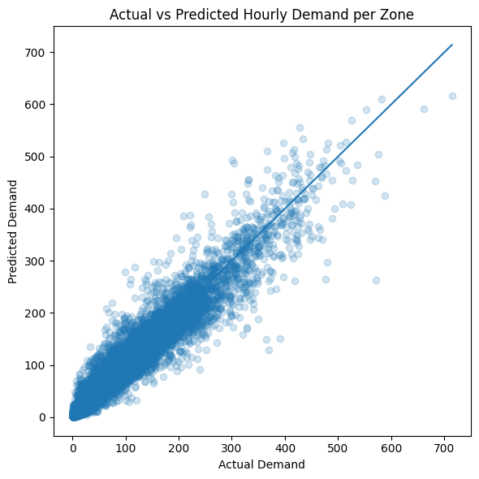

```
Saved: demand_actual_vs_predicted.png
```

```python
pred_df = pd.read_csv("predictions.csv")

# Basic check
required_cols = ["Actual_Demand", "Predicted_Demand"]
for col in required_cols:
    if col not in pred_df.columns:
        raise ValueError(f"Missing column: {col}")

plt.figure(figsize=(6, 6))

plt.scatter(
    pred_df["Actual_Demand"],
    pred_df["Predicted_Demand"],
    alpha=0.2
)

max_val = max(pred_df["Actual_Demand"].max(), pred_df["Predicted_Demand"].max())
plt.plot([0, max_val], [0, max_val])

plt.xlabel("Actual Demand")
plt.ylabel("Predicted Demand")
plt.title("Actual vs Predicted Hourly Demand per Zone")

plt.tight_layout()
plt.show()

plt.savefig("demand_actual_vs_predicted.png", dpi=300)
plt.close()

print("Saved: demand_actual_vs_predicted.png")
```

### Where and when is revenue highest?

This section identifies the most profitable zones at each hour of the day based on average revenue.

By tracking which zones appear most frequently in the top performers, we can:

- identify consistently high-value areas
- understand how profitability shifts throughout the day
- highlight zones that drivers should prioritise at different times

The plot shows how top zones evolve over time, while the summary table highlights which zones dominate overall.

|  | Hour | PULocationID | Zone | Actual_Revenue |
| --- | --- | --- | --- | --- |
| 11 | 0 | 79 | East Village | 3685.440000 |
| 51 | 0 | 249 | West Village | 3301.883528 |
| 67 | 1 | 79 | East Village | 3395.075294 |
| 106 | 1 | 249 | West Village | 2800.690008 |
| 121 | 2 | 79 | East Village | 2619.523529 |
| 137 | 2 | 148 | Lower East Side | 2164.780588 |
| 177 | 3 | 79 | East Village | 1699.657065 |
| 192 | 3 | 148 | Lower East Side | 1570.490000 |
| 254 | 4 | 230 | Times Sq/Theatre District | 983.698235 |
| 221 | 4 | 48 | Clinton East | 905.073532 |
| 306 | 5 | 230 | Times Sq/Theatre District | 1127.238235 |
| 302 | 5 | 186 | Penn Station/Madison Sq West | 796.422941 |
| 359 | 6 | 230 | Times Sq/Theatre District | 1522.290588 |
| 355 | 6 | 186 | Penn Station/Madison Sq West | 1461.351766 |
| 421 | 7 | 236 | Upper East Side North | 2984.360571 |
| 411 | 7 | 186 | Penn Station/Madison Sq West | 2282.065882 |
| 479 | 8 | 236 | Upper East Side North | 4444.278826 |
| 469 | 8 | 186 | Penn Station/Madison Sq West | 3157.545865 |
| 538 | 9 | 236 | Upper East Side North | 4740.665882 |
| 533 | 9 | 230 | Times Sq/Theatre District | 3981.027059 |

[figure not shown]

[output not shown]

```python
df = pd.read_csv("predictions.csv")

zone_hour_revenue = (
    df.groupby(["Hour", "PULocationID", "Zone"])["Actual_Revenue"]
    .mean()
    .reset_index()
)

top5_per_hour = (
    zone_hour_revenue
    .sort_values(["Hour", "Actual_Revenue"], ascending=[True, False])
    .groupby("Hour")
    .head(2)
)

display(top5_per_hour.head(20))

plt.figure(figsize=(12, 6))

for zone in top5_per_hour["Zone"].unique():
    subset = top5_per_hour[top5_per_hour["Zone"] == zone]
    plt.plot(subset["Hour"], subset["Actual_Revenue"], marker="o", label=zone)

plt.xlabel("Hour of Day")
plt.ylabel("Mean Hourly Revenue")
plt.title("Top 5 Most Profitable Zones Per Hour (Average)")
plt.legend(bbox_to_anchor=(1.05, 1), loc='upper left')
plt.tight_layout()
plt.show()

zone_counts = (
    top5_per_hour["Zone"]
    .value_counts()
    .reset_index()
)

zone_counts.columns = ["Zone", "Times in Top 5"]

display(zone_counts.head(10))
```

### How does revenue vary across zones and time?

This heatmap shows average hourly revenue for zones that appear in the top performers at any point in the day.

It provides a compact view of:

- when each zone is most profitable
- how revenue patterns differ across locations
- which zones have consistent vs time-specific demand

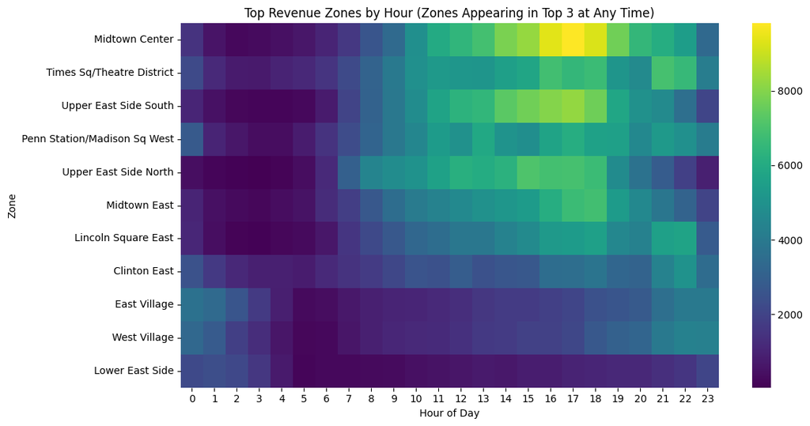

```python
import seaborn as sns

df = pd.read_csv("predictions.csv")

zone_hour = (
    df.groupby(["Zone", "Hour"])["Actual_Revenue"]
    .mean()
    .reset_index()
)

top3_per_hour = (
    zone_hour
    .sort_values(["Hour", "Actual_Revenue"], ascending=[True, False])
    .groupby("Hour")
    .head(3)
)

top_zones_dynamic = top3_per_hour["Zone"].unique()

pivot = (
    zone_hour[zone_hour["Zone"].isin(top_zones_dynamic)]
    .pivot(index="Zone", columns="Hour", values="Actual_Revenue")
)

zone_order = (
    zone_hour[zone_hour["Zone"].isin(top_zones_dynamic)]
    .groupby("Zone")["Actual_Revenue"]
    .mean()
    .sort_values(ascending=False)
    .index
)

pivot = pivot.loc[zone_order]
plt.figure(figsize=(12, 6))
sns.heatmap(pivot, cmap="viridis")

plt.title("Top Revenue Zones by Hour (Zones Appearing in Top 3 at Any Time)")
plt.xlabel("Hour of Day")
plt.ylabel("Zone")
plt.tight_layout()
plt.show()
```

### How does revenue shift across the city throughout the day?

These maps show the spatial distribution of revenue across Manhattan for key time periods:

- morning commute
- daytime
- evening peak
- night / social hours

Revenue is normalised within each time window to highlight relative intensity, making it easier to compare patterns across different periods.

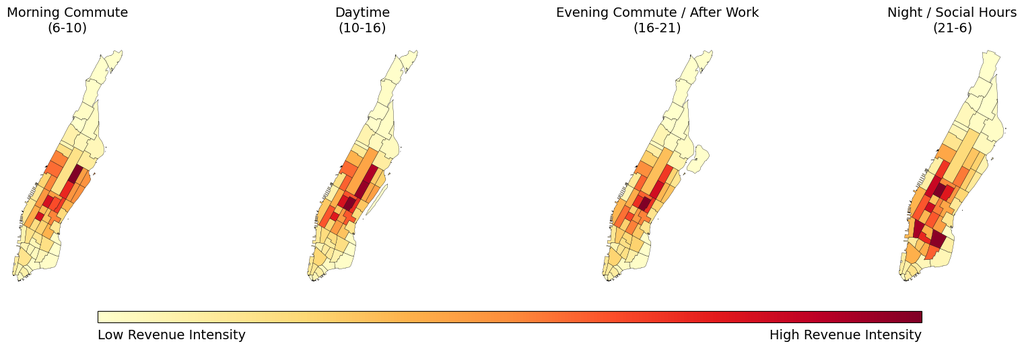

```python
df = pd.read_csv("predictions.csv")

zones = gpd.read_file("data/taxi_zones/taxi_zones.shp")
manhattan = zones[zones["borough"] == "Manhattan"].copy()

def time_bucket(hour):
    if 6 <= hour < 10:
        return "Morning Commute\n(6-10)"
    elif 10 <= hour < 16:
        return "Daytime\n(10-16)"
    elif 16 <= hour < 21:
        return "Evening Commute / After Work\n(16-21)"
    else:
        return "Night / Social Hours\n(21-6)"

df["time_bucket"] = df["Hour"].apply(time_bucket)

agg = (
    df.groupby(["PULocationID", "time_bucket"])["Actual_Revenue"]
    .mean()
    .reset_index()
)

agg.columns = ["LocationID", "time_bucket", "mean_revenue"]

agg["relative_revenue"] = (
    agg.groupby("time_bucket")["mean_revenue"]
    .transform(lambda x: (x - x.min()) / (x.max() - x.min()) if x.max() > x.min() else 0)
)

geo = manhattan.merge(agg, on="LocationID", how="left")

fig, axes = plt.subplots(1, 4, figsize=(18, 5.4))

buckets = [
    "Morning Commute\n(6-10)",
    "Daytime\n(10-16)",
    "Evening Commute / After Work\n(16-21)",
    "Night / Social Hours\n(21-6)"
]

for ax, bucket in zip(axes, buckets):
    subset = geo[geo["time_bucket"] == bucket]

    subset.plot(
        column="relative_revenue",
        ax=ax,
        cmap="YlOrRd",
        edgecolor="black",
        linewidth=0.25,
        vmin=0,
        vmax=1,
        legend=False
    )

    ax.set_title(bucket, fontsize=14, pad=8)
    ax.axis("off")

sm = mpl.cm.ScalarMappable(cmap="YlOrRd", norm=plt.Normalize(0, 1))
sm._A = []

cax = fig.add_axes([0.16, 0.08, 0.68, 0.03])
cbar = fig.colorbar(sm, cax=cax, orientation="horizontal")
cbar.set_ticks([])

fig.text(0.16, 0.045, "Low Revenue Intensity", ha="left", va="center", fontsize=14)
fig.text(0.84, 0.045, "High Revenue Intensity", ha="right", va="center", fontsize=14)

plt.subplots_adjust(left=0.02, right=0.98, top=0.86, bottom=0.16, wspace=0.06)

plt.show()
```

### Which days of the week are most valuable?

This plot compares average revenue by day of week and hour.

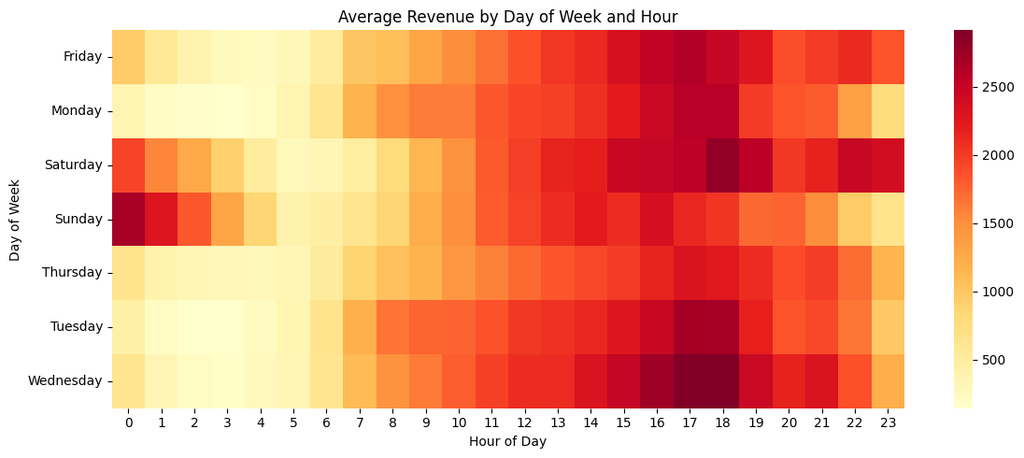

```python
day_hour_revenue = (
    df.groupby(["Day_of_Week", "Hour"])["Actual_Revenue"]
    .mean()
    .reset_index()
    .pivot(index="Day_of_Week", columns="Hour", values="Actual_Revenue")
)

day_labels = {
    0: "Mon", 1: "Tue", 2: "Wed", 3: "Thu",
    4: "Fri", 5: "Sat", 6: "Sun"
}
day_hour_revenue.index = [day_labels.get(i, i) for i in day_hour_revenue.index]

plt.figure(figsize=(12, 5))
sns.heatmap(day_hour_revenue, cmap="YlOrRd")

plt.title("Average Revenue by Day of Week and Hour")
plt.xlabel("Hour of Day")
plt.ylabel("Day of Week")
plt.tight_layout()
plt.show()
```

### When does the model struggle most?

This plot shows how prediction error varies across the day

This is important as these are the times where conservative decisions may be required.

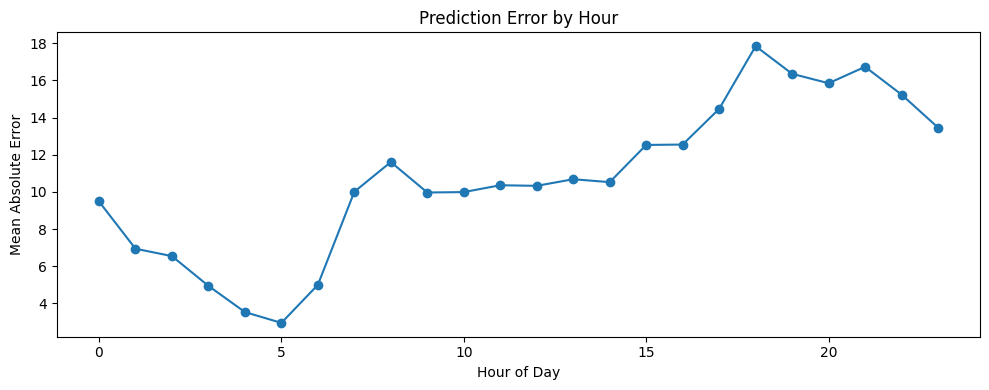

```python
df["abs_error"] = (df["Predicted_Demand"] - df["Actual_Demand"]).abs()

hourly_error = (
    df.groupby("Hour")["abs_error"]
    .mean()
    .reset_index()
)

plt.figure(figsize=(10, 4))
plt.plot(hourly_error["Hour"], hourly_error["abs_error"], marker="o")

plt.xlabel("Hour of Day")
plt.ylabel("Mean Absolute Error")
plt.title("Prediction Error by Hour")

plt.tight_layout()
plt.show()
```

### Does the model systematically underpredict or overpredict?

This plot shows prediction bias (predicted - actual demand) across hours.

It highlights:

- whether the model tends to underpredict during peak demand
- whether it overpredicts in quieter periods

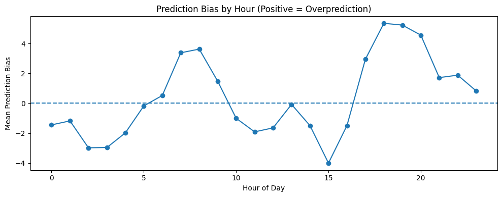

```python
df["bias"] = df["Predicted_Demand"] - df["Actual_Demand"]

hourly_bias = (
    df.groupby("Hour")["bias"]
    .mean()
    .reset_index()
)

plt.figure(figsize=(10, 4))
plt.plot(hourly_bias["Hour"], hourly_bias["bias"], marker="o")
plt.axhline(0, linestyle="--")

plt.xlabel("Hour of Day")
plt.ylabel("Mean Prediction Bias")
plt.title("Prediction Bias by Hour (Positive = Overprediction)")

plt.tight_layout()
plt.show()
```